# Tugas_APG_EFA

Bill Van Ricardo Zalukhu

2022-04-27

```r
library(psych)
library(corrplot)
library("psych")
library(ggplot2)
library(car)
library(openxlsx)
library(dplyr)
```

## 9.10

Jika dilihat dari hasil kedua loadings yang diperoleh antara sebelum dan setelah dirotasi, ternyata hasil loading dari rotasi $varimax$ lebih baik dibanding dengan sebelum dirotasi, sehingga factor loadings yang kita gunakan yaitu yang berasal dari hasil rotasi $varimax$. Tetapi karena kebutuhan soal mengharuskan kita menggunakan $unrotated$, maka factor loadings yang kita gunakan adalah factor loadings yang berasal dari hasil yang sebelum dirotasi.

```r
F_1 <- c(.602, .467, .926, 1, .874, .894)
F_2 <- c(.2, .154, .143, 0, .476, .327)

l_unrotated <- cbind(F_1, F_2)
as.data.frame(l_unrotated)
```

```
##     F_1   F_2
## 1 0.602 0.200
## 2 0.467 0.154
## 3 0.926 0.143
## 4 1.000 0.000
## 5 0.874 0.476
## 6 0.894 0.327
```

```r
R_chicken <- matrix(c(1.000, .505, .569, .602, .621, .603,
              .505, 1.000, .422, .467, .482, .450,
              .569, .422, 1.000, .926, .877, .878,
              .602, .467, .926, 1.000, .874, .894,
              .621, .482, .877, .874, 1.000, .937,
              .603, .450, .878, .894, .937, 1.000
              ), nrow = 6, ncol = 6)
R_chicken
```

```
##       [,1]  [,2]  [,3]  [,4]  [,5]  [,6]
## [1,] 1.000 0.505 0.569 0.602 0.621 0.603
## [2,] 0.505 1.000 0.422 0.467 0.482 0.450
## [3,] 0.569 0.422 1.000 0.926 0.877 0.878
## [4,] 0.602 0.467 0.926 1.000 0.874 0.894
## [5,] 0.621 0.482 0.877 0.874 1.000 0.937
## [6,] 0.603 0.450 0.878 0.894 0.937 1.000
```

1. Untuk menghitung $specific \space variance$, kita bisa menggunakan persamaan berikut:
   $$\tilde{\Psi} = R - \sum_{j=1}^{m}
   l_{ij}^{2}$$

```r
psi_chicken <- matrix(0, 6, 6)
for(i in c(1:6))
  psi_chicken[i, i] <- R_chicken[i,i] - ((l_unrotated[i, 1]^2) + (l_unrotated[i, 2]^2))
as.data.frame(diag(psi_chicken))
```

```
##   diag(psi_chicken)
## 1          0.597596
## 2          0.758195
## 3          0.122075
## 4          0.000000
## 5          0.009548
## 6          0.093835
```

2. $Communalities$ dapat diperoleh menggunakan rumus:
   $$\tilde{h}^2 = l_{i,1}^2
   + l_{i,2}^2 + ... +l_{i,m}^2$$
   maka:

```r
comm_chicken <- matrix(nrow = 6)
for(i in c(1:6))
  comm_chicken[i] <- ((l_unrotated[i, 1]^2) + (l_unrotated[i, 2]^2))
as.data.frame(comm_chicken)
```

```
##         V1
## 1 0.402404
## 2 0.241805
## 3 0.877925
## 4 1.000000
## 5 0.990452
## 6 0.906165
```

Jika kita melihat dari hasil $communalities$ di atas, terlihat bahwa sebagian besar nilainya sudah sangat besar, yang menandakan bahwa model factor yang dibentuk dari data tersebut sudah baik, walau masih ada nilai yang kecil (seperti pada $\tilde{h}_{1}$ dan $\tilde{h}_{2}$)

```r
prop_var_chicken <- colMeans(l_unrotated^2)
prop_var_chicken
```

```
##        F_1        F_2
## 0.66684683 0.06961167
```

```r
tot_prop_chicken <- sum(prop_var_chicken)
tot_prop_chicken
```

```
## [1] 0.7364585
```

Dari hasil proporsi varians yang bisa dijelaskan dari factor yang berasal dari unrotated factor, terlihat bahwa $F_{1}$ bisa menjelaskan $66.68\%$ dari data yang ada, sedangkan $F_{2}$ hanya bisa menjelaskan $6,96\%$ dari data yang ada. Jika kita melihat dari total proporsi varians yang bisa dijelaskan oleh kedua factor ini, terlihat bahwa totalnya sebesar $73,64\%$, yang masih belum dikatakan cukup baik.

4. Berikut rumus dari $residual \space matrix$ yang akan dicari:
   $$R -
   \tilde{L}\tilde{L'} - \tilde{\Psi}$$

```r
res_chicken <- R_chicken - (l_unrotated %*% t(l_unrotated)) - psi_chicken
res_chicken
```

```
##           [,1]      [,2]      [,3] [,4]      [,5]      [,6]
## [1,]  0.000000  0.193066 -0.017052    0 -0.000348 -0.000588
## [2,]  0.193066  0.000000 -0.032464    0  0.000538 -0.017856
## [3,] -0.017052 -0.032464  0.000000    0 -0.000392  0.003395
## [4,]  0.000000  0.000000  0.000000    0  0.000000  0.000000
## [5,] -0.000348  0.000538 -0.000392    0  0.000000 -0.000008
## [6,] -0.000588 -0.017856  0.003395    0 -0.000008  0.000000
```

## 9.19

```r
salespeople_dat <- read.xlsx("C://Users//bilva//OneDrive//Documents//3SI1//Semester 6//Tugas Matkul//tugas_matkul//Analisis Peubah Ganda//Tugas9-221911069-3SI1-Bill Van Ricardo Zalukhu//Salespeople_data.xlsx")
```

Tahap pertama, kita lakukan pengujian KMO untuk menguji kecocokan data apakah bisa dilakukan analisis faktor atau tidak, dan pengujian Bartlett Sphericity untuk menguji apakah antar variabel pada data berkorelasi.

- KMO

```r
KMO(salespeople_dat)
```

```
## Kaiser-Meyer-Olkin factor adequacy
## Call: KMO(r = salespeople_dat)
## Overall MSA =  0.62
## MSA for each item =
##        sales_growth sales_profitability   new_account_sales     creativity_test
##                0.66                0.78                0.63                0.41
## mech_reasoning_test  abs_reasoning_test           math_test
##                0.75                0.42                0.63
```

- Bartlett Sphericity

```r
cortest.bartlett(salespeople_dat)
```

```
## R was not square, finding R from data
```

```
## $chisq
## [1] 499.6613
##
## $p.value
## [1] 1.737779e-92
##
## $df
## [1] 21
```

Jika dilihat dari hasil pengujian Bartlett Sphericity di atas, terlihat bahwa $p-value$ < $\alpha$, sehingga kesimpulan yang didapatkan adalah terdapat fenomena korelasi yang terjadi antar variabel di dalam data. Dari hasil kedua pengujian di atas, dapat kita ambil kesimpulan bahwa data yang digunakan dalam analisis telah cocok untuk dilakukan analisis faktor.

Sesuai dengan instruksi soal, kita harus menormalkan data yang akan dianalisi karena adanya perbedaan tipe data pada variabel.

```r
salespeople_norm <- salespeople_dat %>% mutate_all(~(scale(.) %>% as.vector))
```

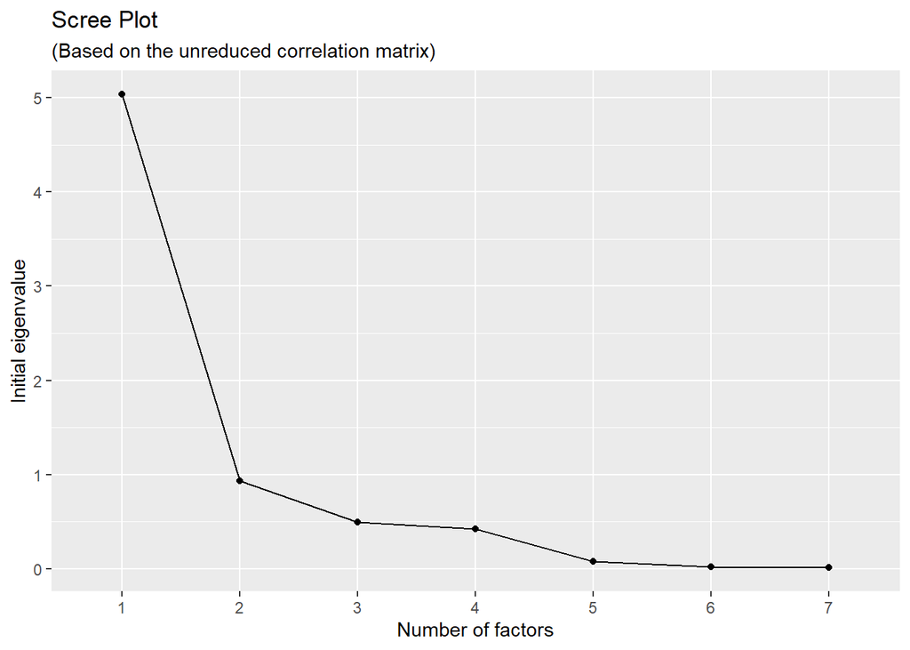

```r
fafitfree <- fa(salespeople_norm,nfactors = ncol(salespeople_norm), rotate = "none")
n_factors <- length(fafitfree$e.values)
scree     <- data.frame(
  Factor_n =  as.factor(1:n_factors),
  Eigenvalue = fafitfree$e.values)
ggplot(scree, aes(x = Factor_n, y = Eigenvalue, group = 1)) +
  geom_point() + geom_line() +
  xlab("Number of factors") +
  ylab("Initial eigenvalue") +
  labs( title = "Scree Plot",
        subtitle = "(Based on the unreduced correlation matrix)")
```

1. a.1. m = 2
- Faktor tidak dirotasi

```r
fa_salespeople_unrotated_m2 <- fa(r = salespeople_norm, nfactors = 2, covar = F, fm = "ml", max.iter = 100, rotate = "none")
print(fa_salespeople_unrotated_m2)
```

```
## Factor Analysis using method =  ml
## Call: fa(r = salespeople_norm, nfactors = 2, rotate = "none", covar = F,
##     max.iter = 100, fm = "ml")
## Standardized loadings (pattern matrix) based upon correlation matrix
##                      ML1   ML2   h2    u2 com
## sales_growth        0.70  0.67 0.93 0.069 2.0
## sales_profitability 0.67  0.69 0.93 0.070 2.0
## new_account_sales   0.80  0.49 0.88 0.123 1.7
## creativity_test     0.98 -0.17 1.00 0.005 1.1
## mech_reasoning_test 0.65  0.31 0.53 0.474 1.4
## abs_reasoning_test  0.25  0.57 0.39 0.614 1.4
## math_test           0.56  0.81 0.97 0.029 1.8
##
##                        ML1  ML2
## SS loadings           3.33 2.28
## Proportion Var        0.48 0.33
## Cumulative Var        0.48 0.80
## Proportion Explained  0.59 0.41
## Cumulative Proportion 0.59 1.00
##
## Mean item complexity =  1.6
## Test of the hypothesis that 2 factors are sufficient.
##
## The degrees of freedom for the null model are  21  and the objective function was  10.9 with Chi Square of  499.66
## The degrees of freedom for the model are 8  and the objective function was  2.63
##
## The root mean square of the residuals (RMSR) is  0.06
## The df corrected root mean square of the residuals is  0.09
##
## The harmonic number of observations is  50 with the empirical chi square  6.79  with prob <  0.56
## The total number of observations was  50  with Likelihood Chi Square =  117.2  with prob <  1.3e-21
##
## Tucker Lewis Index of factoring reliability =  0.382
## RMSEA index =  0.522  and the 90 % confidence intervals are  0.446 0.614
## BIC =  85.9
## Fit based upon off diagonal values = 0.99
## Measures of factor score adequacy
##                                                    ML1  ML2
## Correlation of (regression) scores with factors   1.00 0.99
## Multiple R square of scores with factors          1.00 0.98
## Minimum correlation of possible factor scores     0.99 0.96
```

- Faktor dirotasi dengan metode $varimax$

```r
fa_salespeople_rotated_m2 <- fa(r = salespeople_norm, nfactors = 2, covar = F, fm = "ml", max.iter = 100, rotate = "varimax")
print(fa_salespeople_rotated_m2)
```

```
## Factor Analysis using method =  ml
## Call: fa(r = salespeople_norm, nfactors = 2, rotate = "varimax", covar = F,
##     max.iter = 100, fm = "ml")
## Standardized loadings (pattern matrix) based upon correlation matrix
##                      ML2  ML1   h2    u2 com
## sales_growth        0.85 0.45 0.93 0.069 1.5
## sales_profitability 0.87 0.42 0.93 0.070 1.4
## new_account_sales   0.72 0.60 0.88 0.123 1.9
## creativity_test     0.15 0.99 1.00 0.005 1.0
## mech_reasoning_test 0.50 0.53 0.53 0.474 2.0
## abs_reasoning_test  0.62 0.06 0.39 0.614 1.0
## math_test           0.95 0.28 0.97 0.029 1.2
##
##                        ML2  ML1
## SS loadings           3.54 2.07
## Proportion Var        0.51 0.30
## Cumulative Var        0.51 0.80
## Proportion Explained  0.63 0.37
## Cumulative Proportion 0.63 1.00
##
## Mean item complexity =  1.4
## Test of the hypothesis that 2 factors are sufficient.
##
## The degrees of freedom for the null model are  21  and the objective function was  10.9 with Chi Square of  499.66
## The degrees of freedom for the model are 8  and the objective function was  2.63
##
## The root mean square of the residuals (RMSR) is  0.06
## The df corrected root mean square of the residuals is  0.09
##
## The harmonic number of observations is  50 with the empirical chi square  6.79  with prob <  0.56
## The total number of observations was  50  with Likelihood Chi Square =  117.2  with prob <  1.3e-21
##
## Tucker Lewis Index of factoring reliability =  0.382
## RMSEA index =  0.522  and the 90 % confidence intervals are  0.446 0.614
## BIC =  85.9
## Fit based upon off diagonal values = 0.99
## Measures of factor score adequacy
##                                                    ML2  ML1
## Correlation of (regression) scores with factors   0.99 1.00
## Multiple R square of scores with factors          0.98 0.99
## Minimum correlation of possible factor scores     0.96 0.99
```

a.2. m = 3 - Faktor tidak dirotasi

```r
fa_salespeople_unrotated_m3 <- fa(r = salespeople_norm, nfactors = 3, covar = F, fm = "ml", max.iter = 100, rotate = "none")
print(fa_salespeople_unrotated_m3)
```

```
## Factor Analysis using method =  ml
## Call: fa(r = salespeople_norm, nfactors = 3, rotate = "none", covar = F,
##     max.iter = 100, fm = "ml")
## Standardized loadings (pattern matrix) based upon correlation matrix
##                      ML1   ML3   ML2   h2    u2 com
## sales_growth        0.90  0.38 -0.07 0.96 0.039 1.4
## sales_profitability 0.78  0.60  0.07 0.97 0.034 1.9
## new_account_sales   0.93  0.20  0.06 0.91 0.088 1.1
## creativity_test     0.73 -0.12  0.67 1.00 0.005 2.0
## mech_reasoning_test 0.69  0.22  0.17 0.55 0.447 1.3
## abs_reasoning_test  0.76 -0.13 -0.64 1.00 0.005 2.0
## math_test           0.76  0.61 -0.11 0.96 0.038 2.0
##
##                        ML1  ML3  ML2
## SS loadings           4.44 1.00 0.90
## Proportion Var        0.63 0.14 0.13
## Cumulative Var        0.63 0.78 0.91
## Proportion Explained  0.70 0.16 0.14
## Cumulative Proportion 0.70 0.86 1.00
##
## Mean item complexity =  1.7
## Test of the hypothesis that 3 factors are sufficient.
##
## The degrees of freedom for the null model are  21  and the objective function was  10.9 with Chi Square of  499.66
## The degrees of freedom for the model are 3  and the objective function was  1.42
##
## The root mean square of the residuals (RMSR) is  0.03
## The df corrected root mean square of the residuals is  0.07
##
## The harmonic number of observations is  50 with the empirical chi square  1.43  with prob <  0.7
## The total number of observations was  50  with Likelihood Chi Square =  62.18  with prob <  2e-13
##
## Tucker Lewis Index of factoring reliability =  0.093
## RMSEA index =  0.628  and the 90 % confidence intervals are  0.503 0.776
## BIC =  50.44
## Fit based upon off diagonal values = 1
## Measures of factor score adequacy
##                                                    ML1  ML3  ML2
## Correlation of (regression) scores with factors   1.00 0.98 1.00
## Multiple R square of scores with factors          1.00 0.97 0.99
## Minimum correlation of possible factor scores     0.99 0.94 0.99
```

- Faktor dirotasi dengan metode $varimax$

```r
fa_salespeople_rotated_m3 <- fa(r = salespeople_norm, nfactors = 3, covar = F, fm = "ml", max.iter = 100, rotate = "varimax")
print(fa_salespeople_rotated_m3)
```

```
## Factor Analysis using method =  ml
## Call: fa(r = salespeople_norm, nfactors = 3, rotate = "varimax", covar = F,
##     max.iter = 100, fm = "ml")
## Standardized loadings (pattern matrix) based upon correlation matrix
##                      ML3  ML1  ML2   h2    u2 com
## sales_growth        0.79 0.37 0.44 0.96 0.039 2.0
## sales_profitability 0.91 0.32 0.18 0.97 0.034 1.3
## new_account_sales   0.65 0.54 0.44 0.91 0.088 2.7
## creativity_test     0.26 0.96 0.02 1.00 0.005 1.1
## mech_reasoning_test 0.54 0.47 0.21 0.55 0.447 2.3
## abs_reasoning_test  0.30 0.05 0.95 1.00 0.005 1.2
## math_test           0.92 0.18 0.30 0.96 0.038 1.3
##
##                        ML3  ML1  ML2
## SS loadings           3.17 1.72 1.45
## Proportion Var        0.45 0.25 0.21
## Cumulative Var        0.45 0.70 0.91
## Proportion Explained  0.50 0.27 0.23
## Cumulative Proportion 0.50 0.77 1.00
##
## Mean item complexity =  1.7
## Test of the hypothesis that 3 factors are sufficient.
##
## The degrees of freedom for the null model are  21  and the objective function was  10.9 with Chi Square of  499.66
## The degrees of freedom for the model are 3  and the objective function was  1.42
##
## The root mean square of the residuals (RMSR) is  0.03
## The df corrected root mean square of the residuals is  0.07
##
## The harmonic number of observations is  50 with the empirical chi square  1.43  with prob <  0.7
## The total number of observations was  50  with Likelihood Chi Square =  62.18  with prob <  2e-13
##
## Tucker Lewis Index of factoring reliability =  0.093
## RMSEA index =  0.628  and the 90 % confidence intervals are  0.503 0.776
## BIC =  50.44
## Fit based upon off diagonal values = 1
## Measures of factor score adequacy
##                                                    ML3  ML1  ML2
## Correlation of (regression) scores with factors   0.99 1.00 1.00
## Multiple R square of scores with factors          0.98 0.99 0.99
## Minimum correlation of possible factor scores     0.95 0.98 0.98
```

```r
fa_salespeople_rotated_m2$loadings
```

```
##
## Loadings:
##                     ML2   ML1
## sales_growth        0.852 0.452
## sales_profitability 0.868 0.419
## new_account_sales   0.717 0.602
## creativity_test     0.148 0.987
## mech_reasoning_test 0.501 0.525
## abs_reasoning_test  0.619
## math_test           0.946 0.277
##
##                  ML2   ML1
## SS loadings    3.545 2.071
## Proportion Var 0.506 0.296
## Cumulative Var 0.506 0.802
```

```r
fa_salespeople_rotated_m3$loadings
```

```
##
## Loadings:
##                     ML3   ML1   ML2
## sales_growth        0.793 0.374 0.438
## sales_profitability 0.911 0.317 0.185
## new_account_sales   0.651 0.544 0.438
## creativity_test     0.255 0.964
## mech_reasoning_test 0.542 0.465 0.207
## abs_reasoning_test  0.299       0.950
## math_test           0.917 0.180 0.298
##
##                  ML3   ML1   ML2
## SS loadings    3.175 1.718 1.453
## Proportion Var 0.454 0.245 0.208
## Cumulative Var 0.454 0.699 0.906
```

Beberapa hal yang bisa kita dapatkan dari hasil factor analysis diatas antara lain:

- jika kita melihat dari factor loadings antara hasil faktor yang telah dirotasi antara hasil analisis faktor dengan m = 2 dan m = 3, didapatkan bahwa antar satu faktor dengan faktor yang lainnya sudah memiliki nilai unique loadings nya masing-masing, sehingga ambiguitas pada kasus ini sudah lebih terminimalisir setelah faktor dirotasi, baik faktor dengan m = 2 maupun faktor dengan m = 3;
- jika kita lihat dari proporsi varians kumulatif yang bisa dijelaskan, faktor dengan $m = 3$ memiliki persentase yang sudah sangat tinggi, yaitu $90,7\%$, dibanding dengan faktor dengan $m = 2$ yang hanya sebesar $80,3\%$.
- $Communalities$ ($\tilde{h}_{i}$)

```r
as.data.frame(cbind(fa_salespeople_rotated_m2$communalities, fa_salespeople_rotated_m3$communalities))
```

```
##                            V1        V2
## sales_growth        0.9308084 0.9614288
## sales_profitability 0.9296171 0.9655182
## new_account_sales   0.8766888 0.9118758
## creativity_test     0.9950000 0.9950000
## mech_reasoning_test 0.5264156 0.5533880
## abs_reasoning_test  0.3863585 0.9950000
## math_test           0.9711829 0.9624919
```

- $Uniquenesses$ atau $Specific \space Variance$ ($\tilde{\Psi}_{i}$)

```r
as.data.frame(cbind(fa_salespeople_rotated_m2$uniquenesses, fa_salespeople_rotated_m3$uniquenesses))
```

```
##                              V1          V2
## sales_growth        0.069191515 0.038571357
## sales_profitability 0.070382519 0.034481797
## new_account_sales   0.123310305 0.088124265
## creativity_test     0.004987889 0.004956641
## mech_reasoning_test 0.473588339 0.446619476
## abs_reasoning_test  0.613637151 0.004968310
## math_test           0.028817227 0.037508685
```

- Estimasi Matriks Kovarian dari Data (dalam hal ini karena menggunakan data yang ternormalisasi, maka matriks kovarians data = matriks korelasi data) ($\tilde{L}\tilde{L}' + \tilde{\Psi}_{i}$)

-> matriks korelasi sebenarnya

```r
cor(salespeople_dat)
```

```
##                     sales_growth sales_profitability new_account_sales
## sales_growth           1.0000000           0.9260758         0.8840023
## sales_profitability    0.9260758           1.0000000         0.8425232
## new_account_sales      0.8840023           0.8425232         1.0000000
## creativity_test        0.5720363           0.5415080         0.7003630
## mech_reasoning_test    0.7080738           0.7459097         0.6374712
## abs_reasoning_test     0.6744073           0.4653880         0.6410886
## math_test              0.9273116           0.9442960         0.8525682
##                     creativity_test mech_reasoning_test abs_reasoning_test
## sales_growth              0.5720363           0.7080738          0.6744073
## sales_profitability       0.5415080           0.7459097          0.4653880
## new_account_sales         0.7003630           0.6374712          0.6410886
## creativity_test           1.0000000           0.5907360          0.1469074
## mech_reasoning_test       0.5907360           1.0000000          0.3859502
## abs_reasoning_test        0.1469074           0.3859502          1.0000000
## math_test                 0.4126395           0.5745533          0.5663721
##                     math_test
## sales_growth        0.9273116
## sales_profitability 0.9442960
## new_account_sales   0.8525682
## creativity_test     0.4126395
## mech_reasoning_test 0.5745533
## abs_reasoning_test  0.5663721
## math_test           1.0000000
```

-> untuk m = 2

```r
fa_salespeople_rotated_m2$loadings[, c(1:2)] %*% t(fa_salespeople_rotated_m2$loadings[, c(1:2)]) + diag(fa_salespeople_rotated_m2$uniquenesses)
```

```
##                     sales_growth sales_profitability new_account_sales
## sales_growth           1.0000000           0.9295185         0.8834713
## sales_profitability    0.9295185           1.0000000         0.8749727
## new_account_sales      0.8834713           0.8749727         1.0000000
## creativity_test        0.5720627           0.5413952         0.6996404
## mech_reasoning_test    0.6642314           0.6547844         0.6751659
## abs_reasoning_test     0.5543376           0.5624010         0.4798313
## math_test              0.9311883           0.9373106         0.8449575
##                     creativity_test mech_reasoning_test abs_reasoning_test
## sales_growth              0.5720627           0.6642314          0.5543376
## sales_profitability       0.5413952           0.6547844          0.5624010
## new_account_sales         0.6996404           0.6751659          0.4798313
## creativity_test           1.0000000           0.5918666          0.1504776
## mech_reasoning_test       0.5918666           1.0000000          0.3412918
## abs_reasoning_test        0.1504776           0.3412918          1.0000000
## math_test                 0.4126431           0.6189365          0.6017606
##                     math_test
## sales_growth        0.9311883
## sales_profitability 0.9373106
## new_account_sales   0.8449575
## creativity_test     0.4126431
## mech_reasoning_test 0.6189365
## abs_reasoning_test  0.6017606
## math_test           1.0000000
```

-> untuk m = 3

```r
fa_salespeople_rotated_m3$loadings[, c(1:3)] %*% t(fa_salespeople_rotated_m3$loadings[, c(1:3)]) + diag(fa_salespeople_rotated_m3$uniquenesses)
```

```
##                     sales_growth sales_profitability new_account_sales
## sales_growth           1.0000000           0.9228132         0.9120900
## sales_profitability    0.9228132           1.0000000         0.8471023
## new_account_sales      0.9120900           0.8471023         1.0000000
## creativity_test        0.5714373           0.5417814         0.6991263
## mech_reasoning_test    0.6949346           0.6799445         0.6969684
## abs_reasoning_test     0.6738835           0.4654561         0.6402870
## math_test              0.9255325           0.9481931         0.8255831
##                     creativity_test mech_reasoning_test abs_reasoning_test
## sales_growth              0.5714373           0.6949346          0.6738835
## sales_profitability       0.5417814           0.6799445          0.4654561
## new_account_sales         0.6991263           0.6969684          0.6402870
## creativity_test           1.0000000           0.5910467          0.1469508
## mech_reasoning_test       0.5910467           1.0000000          0.3841949
## abs_reasoning_test        0.1469508           0.3841949          1.0000000
## math_test                 0.4130097           0.6425632          0.5669006
##                     math_test
## sales_growth        0.9255325
## sales_profitability 0.9481931
## new_account_sales   0.8255831
## creativity_test     0.4130097
## mech_reasoning_test 0.6425632
## abs_reasoning_test  0.5669006
## math_test           1.0000000
```

Dari beberapa nilai di atas, berikut beberapa analisisnya:

- jika dilihat dari $communalities$ dan $specific \space variance$ antara kedua hasil, bisa kita simpulkan model faktor dengan $m = 3$ lebih baik karena mayoritas nilai $communalities$ nya sudah besar dan nilai dari $specific \space variance$ sudah kecil dibanding faktor dengan $m = 2$, sehingga dapat disimpulkan bahwa model faktor terbaik yang dapat dibangun diantar kedua jenis hasil analisis ini adalah faktor dengan $m = 3$;
- jika dilihat dari estimasi matriks kovarians antara faktor dengan $m = 2$ dan $m = 3$, jika kita bandingkan dengan matriks korelasi data yang sebenaranya, dapat kita lihat bahwa estimasi matriks kovarians yang cenderung konvergen dan mendekati nilai yang sebenarnya adalah estimasi matriks kovarians dengan $m = 3$. Hal ini dimungkinkan karena tingkat error dari hasil analisis faktornya yang mayoritas lebih rendah.
4. Hipotesis:
   $$H_{0}: \Sigma =
   \tilde{L}\tilde{L}' + \tilde{\Psi}_{i} \\
   H_{1}: \Sigma \not = \tilde{L}\tilde{L}' +
   \tilde{\Psi}_{i}$$

-> untuk m = 2

```r
est_cor_m1 <- fa_salespeople_rotated_m2$loadings[, c(1:2)] %*% t(fa_salespeople_rotated_m2$loadings[, c(1:2)]) + diag(fa_salespeople_rotated_m2$uniquenesses)
```

```r
p <- 7
m1 <- 2
n <- 50

(n - 1 - (2 * p + 4 * m1 + 5)/6) * log(det(est_cor_m1)/det(cor(salespeople_norm)))
```

```
## [1] 117.3066
```

```r
df_m1 <- ((p - m1)^2 - p - m1)/2
qchisq(p = 1 - 0.01, df = df_m1)
```

```
## [1] 20.09024
```

-> untuk m = 3

```r
est_cor_m2 <- fa_salespeople_rotated_m3$loadings[, c(1:3)] %*% t(fa_salespeople_rotated_m3$loadings[, c(1:3)]) + diag(fa_salespeople_rotated_m3$uniquenesses)
```

```r
p <- 7
m2 <- 3
n <- 50

(n - 1 - (2 * p + 4 * m2 + 5)/6) * log(det(est_cor_m2)/det(cor(salespeople_norm)))
```

```
## [1] 62.82397
```

```r
df_m2 <- ((p - m2)^2 - p - m2)/2
qchisq(p = 1 - 0.01, df = df_m2)
```

```
## [1] 11.34487
```

Dari hasil kedua pengujian hipotesis, terlihat bahwa hasil uji statistik dari kedua macam faktor, m = 2 dan m = 3, memiliki nilai yang lebih besar dari nilai statistik tabel $\chi^2_{[(p-m)^2 - p - m]}$, sehingga hasil uji hipotesis nya adalah tolak $H_{0}$. Jika membandingkan antara hasil pada poin (b), (c), dan (d), maka model faktor yang terbaik dibentuk dari faktor dengan $m = 3$.

```r
mean_salespeople <- colMeans(salespeople_dat)
x <- c(110, 98, 105, 15, 18, 12, 35)
z <- matrix(nrow = 7)
for(i in c(1:7)){
  z[i] <- (x[i] - mean_salespeople[i])/sd(salespeople_dat[, i])
}
z
```

```
##            [,1]
## [1,]  1.5215312
## [2,] -0.8516132
## [3,]  0.4647493
## [4,]  0.9569260
## [5,]  1.1285815
## [6,]  0.6730178
## [7,]  0.4972619
```

-> Weigthed Least Square

```r
fa_salespeople_rotated_pca_m3 <- fa(r = salespeople_dat, nfactors = 3, covar = T, fm = "pa", max.iter = 100, rotate = "varimax")
```

```
## maximum iteration exceeded
```

```r
print(fa_salespeople_rotated_pca_m3)
```

```
## Factor Analysis using method =  pa
## Call: fa(r = salespeople_dat, nfactors = 3, rotate = "varimax", covar = T,
##     max.iter = 100, fm = "pa")
## Unstandardized loadings (pattern matrix) based upon covariance matrix
##                      PA1  PA3  PA2    h2   u2   H2     U2
## sales_growth        4.78 4.34 2.95  50.3  3.5 0.93  0.065
## sales_profitability 8.95 3.43 3.84 106.5 -4.0 1.04 -0.039
## new_account_sales   2.22 3.02 2.57  20.7  1.5 0.93  0.070
## creativity_test     0.71 0.81 3.29  12.0  3.6 0.77  0.233
## mech_reasoning_test 1.79 0.48 2.03   7.5  3.9 0.66  0.343
## abs_reasoning_test  0.44 1.48 0.29   2.5  2.1 0.54  0.460
## math_test           7.98 6.45 1.87 108.9  2.2 0.98  0.020
##
##                          PA1   PA3   PA2
## SS loadings           175.45 84.40 48.48
## Proportion Var          0.55  0.26  0.15
## Cumulative Var          0.55  0.81  0.96
## Proportion Explained    0.57  0.27  0.16
## Cumulative Proportion   0.57  0.84  1.00
##
##  Standardized loadings (pattern matrix)
##                     item  PA1  PA3  PA2   h2     u2
## sales_growth           1 0.65 0.59 0.40 0.93  0.065
## sales_profitability    2 0.88 0.34 0.38 1.04 -0.039
## new_account_sales      3 0.47 0.64 0.54 0.93  0.070
## creativity_test        4 0.18 0.21 0.83 0.77  0.233
## mech_reasoning_test    5 0.53 0.14 0.60 0.66  0.343
## abs_reasoning_test     6 0.20 0.69 0.14 0.54  0.460
## math_test              7 0.76 0.61 0.18 0.98  0.020
##
##                  PA1  PA3  PA2
## SS loadings     2.35 1.79 1.70
## Proportion Var  0.34 0.26 0.24
## Cumulative Var  0.34 0.59 0.84
## Cum. factor Var 0.40 0.71 1.00
##
## Mean item complexity =  2
## Test of the hypothesis that 3 factors are sufficient.
##
## The degrees of freedom for the null model are  21  and the objective function was  301.99 with Chi Square of  13841.36
## The degrees of freedom for the model are 3  and the objective function was  1.73
##
## The root mean square of the residuals (RMSR) is  0.58
## The df corrected root mean square of the residuals is  1.53
##
## The harmonic number of observations is  50 with the empirical chi square  706.41  with prob <  8.5e-153
## The total number of observations was  50  with Likelihood Chi Square =  76.04  with prob <  2.2e-16
##
## Tucker Lewis Index of factoring reliability =  0.961
## RMSEA index =  0.698  and the 90 % confidence intervals are  0.573 0.846
## BIC =  64.3
## Fit based upon off diagonal values = 1
```

```r
delta <- t(fa_salespeople_rotated_pca_m3$loadings[, c(1:3)]) %*% solve(diag(fa_salespeople_rotated_pca_m3$uniquenesses)) %*% fa_salespeople_rotated_pca_m3$loadings[, c(1:3)]

solve(delta) %*% t(fa_salespeople_rotated_pca_m3$loadings[, c(1:3)]) %*% solve(diag(fa_salespeople_rotated_pca_m3$uniquenesses)) %*% (x - mean(x))
```

```
##           [,1]
## PA1   9.076057
## PA3 -11.495162
## PA2   8.627639
```

-> Regression

```r
reg <- matrix(nrow = 7)
t(fa_salespeople_rotated_m3$loadings[, c(1:3)]) %*% solve(cor(salespeople_norm)) %*% z
```

```
##           [,1]
## ML3 -0.3285779
## ML1  1.0631891
## ML2  0.7927602
```

## 9.20

Data yang digunakan pada soal ini adalah data yang ada pada tabel 1.5, tetapi cukup menggunakan 4 data saja, yaitu $wind$, $solar \space radiation$, $NO_{2}$, dan $O_{3}$.

```r
wind <- c(8, 7, 7, 10, 6, 8, 9, 5, 7, 8, 6, 6, 7, 10, 10, 9, 8, 8, 9, 9, 10, 9, 8, 5, 6, 8, 6, 8, 6, 10, 8, 7, 5, 6, 10, 8, 5, 5, 7, 7, 6, 8)
solar_rad <- c(98, 107, 103, 88, 91, 90, 84, 72, 82, 64, 71, 91, 72, 70, 72, 77, 76, 71, 67, 69, 62, 88, 80, 30, 83, 84, 78, 79, 62, 37, 71, 52, 48, 75, 35, 85, 86, 86, 79, 79, 68, 40)
no_2 <- c(12, 9, 5, 8, 8, 12, 12, 21, 11, 13, 10, 12, 18, 11, 8, 9, 7, 16, 13, 9, 14, 7, 13, 5, 10, 7, 11, 7, 9, 7, 10, 12, 8, 10, 6, 9, 6, 13, 9, 8, 11, 6)
o_3 <- c(8, 5, 6, 15, 10, 12, 15, 14, 11, 9, 3, 7, 10, 7, 10, 10, 7, 4, 2, 5, 4, 6, 11, 2, 23, 6, 11, 10, 8, 2, 7, 8, 4, 24, 9, 10, 12, 18, 25, 6, 14, 5)

air_pollution_v2 <- cbind(wind, solar_rad, no_2, o_3)
```

```r
S_poll <- cov(air_pollution_v2)
S_poll
```

```
##                 wind  solar_rad       no_2       o_3
## wind       2.5000000  -2.780488 -0.5853659 -2.231707
## solar_rad -2.7804878 300.515679  6.7630662 30.790941
## no_2      -0.5853659   6.763066 11.3635308  3.126597
## o_3       -2.2317073  30.790941  3.1265970 30.978513
```

Dari hasil matriks kovarian di atas, bisa kita lihat bahwa data memiliki variasi nilai varians yang sangat beragam dan skalanya berbeda jauh dikarenakan satuan dari setiap variabel nya yang berbeda satu sama lain. Dapat kita simpulkan bahwa secara general, data sangat bervariasi.

```r
KMO(air_pollution_v2)
```

```
## Kaiser-Meyer-Olkin factor adequacy
## Call: KMO(r = air_pollution_v2)
## Overall MSA =  0.59
## MSA for each item =
##      wind solar_rad      no_2       o_3
##      0.61      0.58      0.70      0.56
```

```r
cortest.bartlett(air_pollution_v2)
```

```
## R was not square, finding R from data
```

```
## $chisq
## [1] 8.22784
##
## $p.value
## [1] 0.2218819
##
## $df
## [1] 6
```

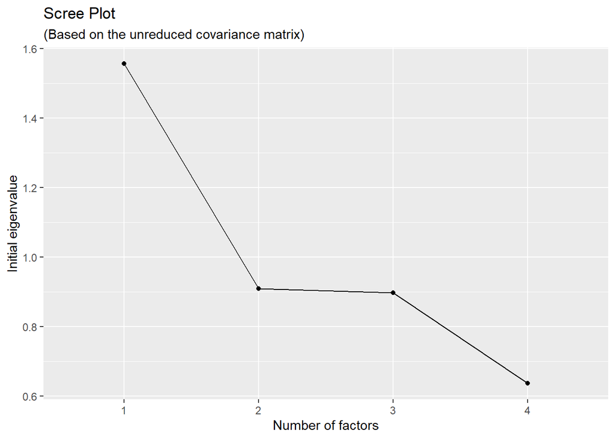

```r
library(ggplot2)
fafitfree <- fa(air_pollution_v2,nfactors = ncol(air_pollution_v2), rotate = "none")
n_factors <- length(fafitfree$e.values)
scree     <- data.frame(
  Factor_n =  as.factor(1:n_factors),
  Eigenvalue = fafitfree$e.values)
ggplot(scree, aes(x = Factor_n, y = Eigenvalue, group = 1)) +
  geom_point() + geom_line() +
  xlab("Number of factors") +
  ylab("Initial eigenvalue") +
  labs( title = "Scree Plot",
        subtitle = "(Based on the unreduced covariance matrix)")
```

Jika dilihat dari scree plot di atas, jumlah factor yang baik yaitu sebanyak 2 faktor yang bisa digunakan dalam melakukan analisis. Tetapi karena kebutuhan pengerjaan soal, kita akan menggunakan variasi data faktor, yaitu 1 faktor dan 2 faktor dengan 2 metode analisis, yaitu $PCA$ dan $MLE$

1. a.1. m = 1
- Tidak merotasi faktor

```r
fa_pca_unrotated1 <- fa(r = air_pollution_v2, nfactors = 1, covar = T, fm = "pa", max.iter = 100, rotate = "none")
```

```
## maximum iteration exceeded
```

```r
print(fa_pca_unrotated1)
```

```
## Factor Analysis using method =  pa
## Call: fa(r = air_pollution_v2, nfactors = 1, rotate = "none", covar = T,
##     max.iter = 100, fm = "pa")
## Unstandardized loadings (pattern matrix) based upon covariance matrix
##             PA1    h2    u2    H2   U2
## wind      -0.43  0.18   2.3 0.072 0.93
## solar_rad  7.18 51.51 249.0 0.171 0.83
## no_2       0.89  0.79  10.6 0.069 0.93
## o_3        4.28 18.35  12.6 0.592 0.41
##
##                  PA1
## SS loadings    70.83
## Proportion Var  0.21
##
##  Standardized loadings (pattern matrix)
##           V   PA1    h2   u2
## wind      1 -0.27 0.072 0.93
## solar_rad 2  0.41 0.171 0.83
## no_2      3  0.26 0.069 0.93
## o_3       4  0.77 0.592 0.41
##
##                 PA1
## SS loadings    0.82
## Proportion Var 0.21
##
## Mean item complexity =  1
## Test of the hypothesis that 1 factor is sufficient.
##
## The degrees of freedom for the null model are  6  and the objective function was  329.08 with Chi Square of  12779.43
## The degrees of freedom for the model are 2  and the objective function was  0.01
##
## The root mean square of the residuals (RMSR) is  0.39
## The df corrected root mean square of the residuals is  0.67
##
## The harmonic number of observations is  42 with the empirical chi square  75.45  with prob <  4.1e-17
## The total number of observations was  42  with Likelihood Chi Square =  0.26  with prob <  0.88
##
## Tucker Lewis Index of factoring reliability =  1
## RMSEA index =  0  and the 90 % confidence intervals are  0 0.153
## BIC =  -7.21
## Fit based upon off diagonal values = 1
## Measures of factor score adequacy
##                                                    PA1
## Correlation of (regression) scores with factors   0.80
## Multiple R square of scores with factors          0.64
## Minimum correlation of possible factor scores     0.29
```

- Dengan merotasi faktor

```r
fa_pca_rotated1 <- fa(r = air_pollution_v2, nfactors = 1, covar = T, fm = "pa", max.iter = 100, rotate = "varimax")
```

```
## maximum iteration exceeded
```

```r
print(fa_pca_rotated1)
```

```
## Factor Analysis using method =  pa
## Call: fa(r = air_pollution_v2, nfactors = 1, rotate = "varimax", covar = T,
##     max.iter = 100, fm = "pa")
## Unstandardized loadings (pattern matrix) based upon covariance matrix
##             PA1    h2    u2    H2   U2
## wind      -0.43  0.18   2.3 0.072 0.93
## solar_rad  7.18 51.51 249.0 0.171 0.83
## no_2       0.89  0.79  10.6 0.069 0.93
## o_3        4.28 18.35  12.6 0.592 0.41
##
##                  PA1
## SS loadings    70.83
## Proportion Var  0.21
##
##  Standardized loadings (pattern matrix)
##           V   PA1    h2   u2
## wind      1 -0.27 0.072 0.93
## solar_rad 2  0.41 0.171 0.83
## no_2      3  0.26 0.069 0.93
## o_3       4  0.77 0.592 0.41
##
##                 PA1
## SS loadings    0.82
## Proportion Var 0.21
##
## Mean item complexity =  1
## Test of the hypothesis that 1 factor is sufficient.
##
## The degrees of freedom for the null model are  6  and the objective function was  329.08 with Chi Square of  12779.43
## The degrees of freedom for the model are 2  and the objective function was  0.01
##
## The root mean square of the residuals (RMSR) is  0.39
## The df corrected root mean square of the residuals is  0.67
##
## The harmonic number of observations is  42 with the empirical chi square  75.45  with prob <  4.1e-17
## The total number of observations was  42  with Likelihood Chi Square =  0.26  with prob <  0.88
##
## Tucker Lewis Index of factoring reliability =  1
## RMSEA index =  0  and the 90 % confidence intervals are  0 0.153
## BIC =  -7.21
## Fit based upon off diagonal values = 1
## Measures of factor score adequacy
##                                                    PA1
## Correlation of (regression) scores with factors   0.80
## Multiple R square of scores with factors          0.64
## Minimum correlation of possible factor scores     0.29
```

a.2. m = 2 - Tidak merotasi faktor

```r
eig_poll <- eigen(S_poll)
eig_poll_val <- eig_poll$values
eig_poll_vec <- eig_poll$vector
```

```r
l_poll_m2 <- matrix(nrow = 4, ncol = 2)
for(i in c(1:2)){
  for(j in c(1:4)){
    l_poll_m2[j, i] <- sqrt(eig_poll_val[i]) * eig_poll_vec[j, i]
  }
}
as.data.frame(l_poll_m2)
```

```
##            V1         V2
## 1   0.1749782  0.4048141
## 2 -17.3246829  0.6085601
## 3  -0.4213923 -0.7421918
## 4  -1.9587473 -5.1867451
```

```r
h2 <- (l_poll_m2[, 1]^2) + (l_poll_m2[, 2]^2)
h2
```

```
## [1]   0.1944918 300.5149843   0.7284201  30.7390159
```

```r
psi_poll <- diag(diag(S_poll)) - diag(h2)
psi_poll
```

```
##          [,1]         [,2]     [,3]      [,4]
## [1,] 2.305508 0.0000000000  0.00000 0.0000000
## [2,] 0.000000 0.0006951005  0.00000 0.0000000
## [3,] 0.000000 0.0000000000 10.63511 0.0000000
## [4,] 0.000000 0.0000000000  0.00000 0.2394974
```

```r
cov(air_pollution_v2)
```

```
##                 wind  solar_rad       no_2       o_3
## wind       2.5000000  -2.780488 -0.5853659 -2.231707
## solar_rad -2.7804878 300.515679  6.7630662 30.790941
## no_2      -0.5853659   6.763066 11.3635308  3.126597
## o_3       -2.2317073  30.790941  3.1265970 30.978513
```

```r
l_poll_m2 %*% t(l_poll_m2) + psi_poll
```

```
##            [,1]       [,2]       [,3]      [,4]
## [1,]  2.5000000  -2.785088 -0.3741842 -2.442406
## [2,] -2.7850881 300.515679  6.8488198 30.778229
## [3,] -0.3741842   6.848820 11.3635308  4.674961
## [4,] -2.4424058  30.778229  4.6749605 30.978513
```

2. b.1. m = 1
- Faktor tidak dirotasi

```r
fa_mle_unrotated1 <- fa(r = cov(air_pollution_v2), nfactors = 1, covar = T, fm = "ml", max.iter = 100, rotate = "none")

print(fa_mle_unrotated1)
```

```
## Factor Analysis using method =  ml
## Call: fa(r = cov(air_pollution_v2), nfactors = 1, rotate = "none",
##     covar = T, max.iter = 100, fm = "ml")
## Unstandardized loadings (pattern matrix) based upon covariance matrix
##             ML1      h2   u2    H2   U2
## wind      -0.19   0.035  2.5 0.014 0.99
## solar_rad 16.39 268.483 32.0 0.893 0.11
## no_2       0.44   0.190 11.2 0.017 0.98
## o_3        1.91   3.636 27.3 0.117 0.88
##
##                   ML1
## SS loadings    272.34
## Proportion Var   0.79
##
##  Standardized loadings (pattern matrix)
##           V   ML1    h2   u2
## wind      1 -0.12 0.014 0.99
## solar_rad 2  0.95 0.893 0.11
## no_2      3  0.13 0.017 0.98
## o_3       4  0.34 0.117 0.88
##
##                 ML1
## SS loadings    3.15
## Proportion Var 0.79
##
## Mean item complexity =  1
## Test of the hypothesis that 1 factor is sufficient.
##
## The degrees of freedom for the null model are  6  and the objective function was  329.08
## The degrees of freedom for the model are 2  and the objective function was  0.08
##
## The root mean square of the residuals (RMSR) is  1.26
## The df corrected root mean square of the residuals is  2.18
##
## Fit based upon off diagonal values = 1
## Measures of factor score adequacy
##                                                    ML1
## Correlation of (regression) scores with factors   0.95
## Multiple R square of scores with factors          0.90
## Minimum correlation of possible factor scores     0.79
```

- Faktor dirotasi

```r
fa_mle_rotated1 <- fa(r = cov(air_pollution_v2), nfactors = 1, covar = T, fm = "ml", max.iter = 100, rotate = "varimax")

print(fa_mle_rotated1)
```

```
## Factor Analysis using method =  ml
## Call: fa(r = cov(air_pollution_v2), nfactors = 1, rotate = "varimax",
##     covar = T, max.iter = 100, fm = "ml")
## Unstandardized loadings (pattern matrix) based upon covariance matrix
##             ML1      h2   u2    H2   U2
## wind      -0.19   0.035  2.5 0.014 0.99
## solar_rad 16.39 268.483 32.0 0.893 0.11
## no_2       0.44   0.190 11.2 0.017 0.98
## o_3        1.91   3.636 27.3 0.117 0.88
##
##                   ML1
## SS loadings    272.34
## Proportion Var   0.79
##
##  Standardized loadings (pattern matrix)
##           V   ML1    h2   u2
## wind      1 -0.12 0.014 0.99
## solar_rad 2  0.95 0.893 0.11
## no_2      3  0.13 0.017 0.98
## o_3       4  0.34 0.117 0.88
##
##                 ML1
## SS loadings    3.15
## Proportion Var 0.79
##
## Mean item complexity =  1
## Test of the hypothesis that 1 factor is sufficient.
##
## The degrees of freedom for the null model are  6  and the objective function was  329.08
## The degrees of freedom for the model are 2  and the objective function was  0.08
##
## The root mean square of the residuals (RMSR) is  1.26
## The df corrected root mean square of the residuals is  2.18
##
## Fit based upon off diagonal values = 1
## Measures of factor score adequacy
##                                                    ML1
## Correlation of (regression) scores with factors   0.95
## Multiple R square of scores with factors          0.90
## Minimum correlation of possible factor scores     0.79
```

b.2. m = 2 - Faktor tidak dirotasi

```r
fa_mle_unrotated2 <- fa(r=cov(air_pollution_v2), nfactors = 2, covar = T, fm = "ml", max.iter = 100, rotate = "none")

print(fa_mle_unrotated2)
```

```
## Factor Analysis using method =  ml
## Call: fa(r = cov(air_pollution_v2), nfactors = 2, rotate = "none",
##     covar = T, max.iter = 100, fm = "ml")
## Unstandardized loadings (pattern matrix) based upon covariance matrix
##             ML1   ML2     h2   u2    H2   U2
## wind      -0.20 -0.64   0.45  2.1 0.179 0.82
## solar_rad 16.37 -0.79 268.64 31.9 0.894 0.11
## no_2       0.45  0.78   0.80 10.6 0.071 0.93
## o_3        2.02  2.86  12.26 18.7 0.396 0.60
##
##                          ML1  ML2
## SS loadings           272.34 9.81
## Proportion Var          0.79 0.03
## Cumulative Var          0.79 0.82
## Proportion Explained    0.97 0.03
## Cumulative Proportion   0.97 1.00
##
##  Standardized loadings (pattern matrix)
##           item   ML1   ML2    h2   u2
## wind         1 -0.13 -0.40 0.179 0.82
## solar_rad    2  0.94 -0.05 0.894 0.11
## no_2         3  0.13  0.23 0.071 0.93
## o_3          4  0.36  0.51 0.396 0.60
##
##                  ML1  ML2
## SS loadings     1.06 0.48
## Proportion Var  0.26 0.12
## Cumulative Var  0.26 0.38
## Cum. factor Var 0.69 1.00
##
## Mean item complexity =  1.4
## Test of the hypothesis that 2 factors are sufficient.
##
## The degrees of freedom for the null model are  6  and the objective function was  329.08
## The degrees of freedom for the model are -1  and the objective function was  0
##
## The root mean square of the residuals (RMSR) is  0
## The df corrected root mean square of the residuals is  NA
##
## Fit based upon off diagonal values = 1
## Measures of factor score adequacy
##                                                    ML1   ML2
## Correlation of (regression) scores with factors   0.95  0.64
## Multiple R square of scores with factors          0.90  0.42
## Minimum correlation of possible factor scores     0.79 -0.17
```

- Faktor dirotasi

```r
fa_mle_rotated2 <- fa(r=cov(air_pollution_v2), nfactors = 2, covar = T, fm = "ml", max.iter = 100, rotate = "varimax")

print(fa_mle_rotated2)
```

```
## Factor Analysis using method =  ml
## Call: fa(r = cov(air_pollution_v2), nfactors = 2, rotate = "varimax",
##     covar = T, max.iter = 100, fm = "ml")
## Unstandardized loadings (pattern matrix) based upon covariance matrix
##             ML1   ML2     h2   u2    H2   U2
## wind      -0.04 -0.67   0.45  2.1 0.179 0.82
## solar_rad 16.06  3.27 268.64 31.9 0.894 0.11
## no_2       0.25  0.86   0.80 10.6 0.071 0.93
## o_3        1.25  3.27  12.26 18.7 0.396 0.60
##
##                          ML1   ML2
## SS loadings           259.55 22.60
## Proportion Var          0.75  0.07
## Cumulative Var          0.75  0.82
## Proportion Explained    0.92  0.08
## Cumulative Proportion   0.92  1.00
##
##  Standardized loadings (pattern matrix)
##           item   ML1   ML2    h2   u2
## wind         1 -0.02 -0.42 0.179 0.82
## solar_rad    2  0.93  0.19 0.894 0.11
## no_2         3  0.07  0.26 0.071 0.93
## o_3          4  0.22  0.59 0.396 0.60
##
##                  ML1  ML2
## SS loadings     0.91 0.62
## Proportion Var  0.23 0.16
## Cumulative Var  0.23 0.38
## Cum. factor Var 0.59 1.00
##
## Mean item complexity =  1.1
## Test of the hypothesis that 2 factors are sufficient.
##
## The degrees of freedom for the null model are  6  and the objective function was  329.08
## The degrees of freedom for the model are -1  and the objective function was  0
##
## The root mean square of the residuals (RMSR) is  0
## The df corrected root mean square of the residuals is  NA
##
## Fit based upon off diagonal values = 1
## Measures of factor score adequacy
##                                                    ML1   ML2
## Correlation of (regression) scores with factors   0.93  0.67
## Multiple R square of scores with factors          0.87  0.45
## Minimum correlation of possible factor scores     0.73 -0.11
```